# Density Histogram

load airquality (preloaded) dataset

```r
data(airquality)
```

take a peek

```r
head(airquality)
```

```
  Ozone Solar.R Wind Temp Month Day
1    41     190  7.4   67     5   1
2    36     118  8.0   72     5   2
3    12     149 12.6   74     5   3
4    18     313 11.5   62     5   4
5    NA      NA 14.3   56     5   5
6    28      NA 14.9   66     5   6
```

calculating mean and stdev, saving off as variables

```r
m<-mean(airquality$Temp)
std<-sd(airquality$Temp)
print(paste0("Mean is: ", m))
```

```
[1] "Mean is: 77.8823529411765"
```

```r
print(paste0("StdDev is: ", std))
```

```
[1] "StdDev is: 9.46526974097146"
```

Let’s create a histogram with base R graphics

```
"add" is not a graphical parameter
```

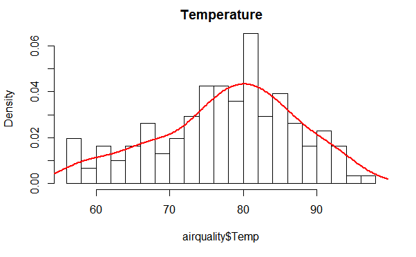

```r
hist(airquality$Temp, breaks=20, freq=F, main="Temperature")
lines(density(airquality$Temp), col="red", lwd=2, add=TRUE)
```

note, `prob` is the argument for `probability = TRUE` you can also get a density histogram by setting `frequency = FALSE` default is `freq=TRUE`

It’s helpful to know: R will match partial words when looking for arguments, which is sometimes useful in keeping your code more concise. But be careful, and make sure it’s understandable!

The line drawn here is the `density` distribution for the data we observed, basically just a smoothing of the peaks on the histogram.

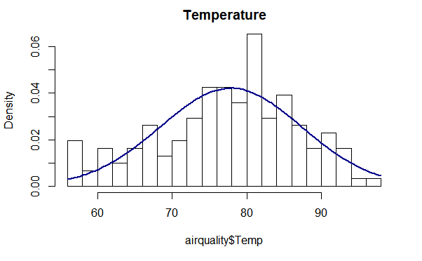

```r
hist(airquality$Temp, breaks=20, freq=F, main="Temperature") #same
curve(dnorm(x, mean=m, sd=std), col="darkblue", lwd=2, add=TRUE)
```

This code adds a normal distribution (‘bell curve’) overlay, fit to our data - meaning centered at the mean, and with the standard deviation (spread) matched to our distribution. You can see our data is approximately normal.

You can also put both on the same graph if you’d like.

```r
hist(airquality$Temp, breaks=20, freq=F, main="Temperature") #same
curve(dnorm(x, mean=m, sd=std), col="darkblue", lwd=2, add=TRUE)
```

```
"add" is not a graphical parameter
```

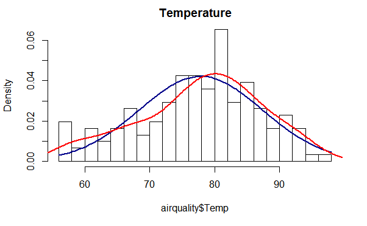

```r
lines(density(airquality$Temp), col="red", lwd=2, add=TRUE)
```

### GGplot2

If you’re curious about the ggplot version, it’s more verbose as you can see below.  
But more arguments = more flexible = more chances to make mistakes  
You don’t **need** to have the `fill gradient`, but it’s an example of an extra feature in ggplot you can’t do in base graphics

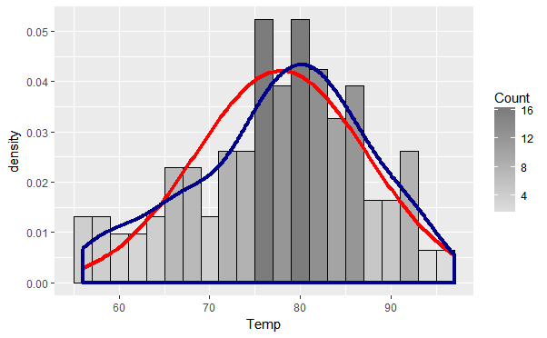

```r
library(ggplot2)
g<-ggplot(airquality, aes(x=Temp))
g<-g + geom_histogram(aes(y=..density.., fill=..count..),
                 binwidth = 2, color="black")
g<-g + scale_fill_gradient("Count", low="#DCDCDC", high="#7C7C7C")
g<-g + stat_function(fun=dnorm, color="red", lwd=1.5,
                args=list(mean=m, sd=std))
g<-g + geom_density(lwd=1.5, color="darkblue")
g
```

Read more: https://www.r-bloggers.com/normal-distribution-functions/